# Exemplo RMD

Jordão Alves

12/10/2019

Neste exemplo de relatório em RMarkdown iremos contabilizar e expor em forma de Treemap as palavras contidas nas versões da canção “O Que Será?” composta por Chico Buarque em 1976 para o filme “Dona Flor e Seus Dois Maridos” que foi baseado no livro de Jorge Amado. Essa canção tem três versões:

- O Que Será? (Abertura)
- O Que Será? (À flor da pele)
- O Que Será? (À Flor da Terra)

## Criando função auxiliar

Criando uma função que pega o conjunto de strings da letra da música e cria um Treemap das palavras disponíveis para sua plotagem. Repare que na função foram eliminados alguns conectivos para exibição das palavras ficarem mais claras.

```r
library(stringr)
library(dplyr)
library(treemap)
vetorPalavras <- function(string,titulo){

## colocando tudo em minusculo
string <- str_to_lower(string)
## separando primeiramente por linha
sepLinha <- str_split(string, fixed('\n'))
sepLinha <- paste(sepLinha[[1]],collapse = " ")
## removendo caracteres
sepLinha <- str_replace_all(sepLinha, "[,.!?]", "")
## separando por espaço
sepEspaco <- str_split(sepLinha, fixed(' '))
vetorPalavras <- as.factor(sepEspaco[[1]])

dados <- aggregate(x = vetorPalavras,
                   by = list(palavras = vetorPalavras),
                   FUN = length)

## filtrando os dados, eliminando algumas palavras conectivas
dadosFiltrados <- dados%>%
  filter( palavras != "a" & palavras != "o" & palavras != "as" & palavras != "os" &
          palavras != "é" & palavras != "e" & palavras != "são" & palavras != "à" &
          palavras != "da" & palavras != "das" & palavras != "do" & palavras != "dos" &
          palavras != "na" & palavras != "no" & palavras != "de" & palavras != "se" &
          palavras != "nas" & palavras != "nos" & palavras != "em" & palavras != "um" &
          palavras != "às" & palavras != "aos" & palavras != "ao" & palavras != "" )

treemap(dadosFiltrados,
        index="palavras",
        vSize="x",
        vColor="x",
        type="value",
        palette="RdYlBu",
        format.legend = list(scientific = FALSE, big.mark = " "
        ),title.legend="Número de palavras",
        title=titulo)
}
```

## O Que Será? (Abertura)

> E todos os meu nervos estão a rogar  
> E todos os meus órgãos estão a clamar  
> E uma aflição medonha me faz implorar  
> O que não tem vergonha, nem nunca terá  
> O que não tem governo, nem nunca terá  
> O que não tem juízo

> O que será que lhe dá  
> O que será meu nego, será que lhe dá  
> Que não lhe dá sossego, será que lhe dá  
> Será que o meu chamego quer me judiar  
> Será que isso são horas dele vadiar  
> Será que passa fora o resto da dia  
> Será que foi-se embora em má companhia  
> Será que essa criança quer me agoniar  
> Será que não se cansa de desafiar  
> O que não tem descanso, nem nunca terá  
> O que não tem cansaço, nem nunca terá  
> O que não tem limite

> O que será que será  
> Que dá dentro da gente, que não devia  
> Que desacata a gente, que é revelia  
> Que é feito uma aguardente que não sacia  
> Que é feito estar doente de um folia  
> Que nem dez mandamentos vão conciliar  
> Nem todos os unguentos vão aliviar  
> Nem todos os quebrantos, toda alquimia  
> E nem todos os santos, será que será  
> O que não tem governo, nem nunca terá  
> O que não tem vergonha, nem nunca terá  
> O que não tem juízo

> Chico Buarque de Holanda

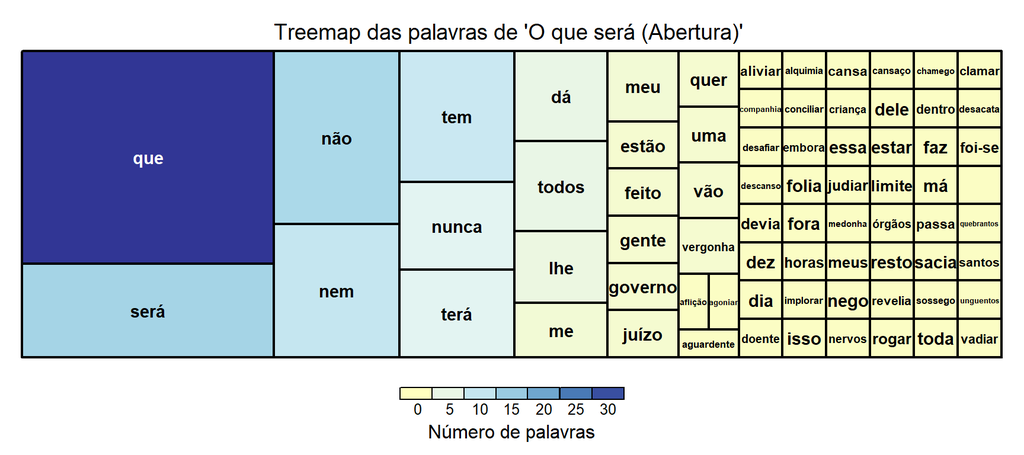

## O Que Será? (À Flor da Pele)

> O que será que me dá  
> Que me bole por dentro, será que me dá  
> Que brota à flor da pele, será que me dá  
> E que me sobe às faces e me faz corar  
> E que me salta aos olhos a me atraiçoar  
> E que me aperta o peito e me faz confessar  
> O que não tem mais jeito de dissimular  
> E que nem é direito ninguém recusar  
> E que me faz mendigo, me faz suplicar  
> O que não tem medida, nem nunca terá  
> O que não tem remédio, nem nunca terá  
> O que não tem receita

> O que será que será  
> Que dá dentro da gente e que não devia  
> Que desacata a gente, que é revelia  
> Que é feito uma aguardente que não sacia  
> Que é feito estar doente de uma folia  
> Que nem dez mandamentos vão conciliar  
> Nem todos os unguentos vão aliviar  
> Nem todos os quebrantos, toda alquimia  
> E nem todos os santos, será que será  
> O que não tem descanso, nem nunca terá  
> O que não tem cansaço, nem nunca terá  
> O que não tem limite

> O que será que me dá  
> Que me queima por dentro, será que me dá  
> Que me perturba o sono, será que me dá  
> Que todos os tremores me vêm agitar  
> Que todos os ardores me vêm atiçar  
> Que todos os suores me vêm encharcar  
> Que todos os meus nervos estão a rogar  
> Que todos os meus órgãos estão a clamar  
> E uma aflição medonha me faz implorar  
> O que não tem vergonha, nem nunca terá  
> O que não tem governo, nem nunca terá  
> O que não tem juízo

> Chico Buarque de Holanda

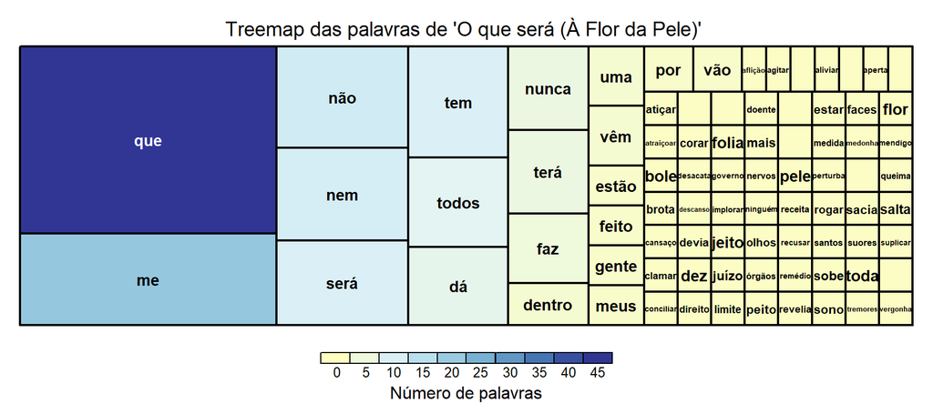

## O Que Será? (À Flor da Terra)

> O que será, que será?  
> Que andam suspirando pelas alcovas  
> Que andam sussurrando em versos e trovas  
> Que andam combinando no breu das tocas  
> Que anda nas cabeças, anda nas bocas  
> Que andam acendendo velas nos becos  
> Que estão falando alto pelos botecos  
> E gritam nos mercados que com certeza  
> Está na natureza

> Será, que será?  
> O que não tem certeza nem nunca terá  
> O que não tem conserto nem nunca terá  
> O que não tem tamanho

> O que será, que será?  
> Que vive nas ideias desses amantes  
> Que cantam os poetas mais delirantes  
> Que juram os profetas embriagados  
> Que está na romaria dos mutilados  
> Que está na fantasia dos infelizes  
> Que está no dia a dia das meretrizes  
> No plano dos bandidos, dos desvalidos  
> Em todos os sentidos

> Será, que será?  
> O que não tem decência nem nunca terá  
> O que não tem censura nem nunca terá  
> O que não faz sentido

> O que será, que será?  
> Que todos os avisos não vão evitar  
> Por que todos os risos vão desafiar  
> Por que todos os sinos irão repicar  
> Por que todos os hinos irão consagrar  
> E todos os meninos vão desembestar  
> E todos os destinos irão se encontrar  
> E mesmo o Padre Eterno que nunca foi lá  
> Olhando aquele inferno vai abençoar  
> O que não tem governo nem nunca terá  
> O que não tem vergonha nem nunca terá  
> O que não tem juízo

> O que será, que será?  
> Que todos os avisos não vão evitar  
> Por que todos os risos vão desafiar  
> Por que todos os sinos irão repicar  
> Por que todos os hinos irão consagrar  
> E todos os meninos vão desembestar  
> E todos os destinos irão se encontrar  
> E mesmo o Padre Eterno que nunca foi lá  
> Olhando aquele inferno vai abençoar  
> O que não tem governo nem nunca terá  
> O que não tem vergonha nem nunca terá  
> O que não tem juízo

> Chico Buarque de Holanda

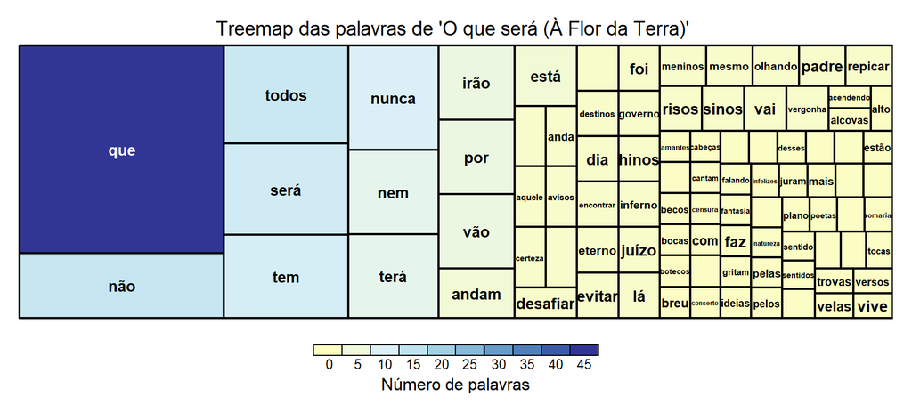

```r
vetorPalavras(aFlorDaTerra,"Treemap das palavras de 'O que será (À Flor da Terra)' ")
```